# week3

# Chapter1. 모델링을 위한 전처리

### 문제 0 기본 세팅. tidyverse, data.table, gridExtra를 부른 후, setwd로 ‘data.csv’ 및 ‘test.csv’가 있는폴더로 경로를 설정하고, fread로 ‘data.csv’와 ‘test.csv’를 불러오세요.

```r
library(tidyverse)
library(data.table)
library(gridExtra)
setwd("C:/Users/jhlee/Documents/package_week3")
mydata <- fread("data.csv")
mytest <- fread("test.csv")
```

### 문제 1. ‘bmi(bmi 지수)’ 변수를 numeric 자료형으로 바꾸고, NA값을 mean imputation으로 채우세요.

```r
mydata$bmi <- as.numeric(mydata$bmi)
mydata$bmi <- ifelse(is.na(mydata$bmi), mean(mydata$bmi,na.rm= T),mydata$bmi)
```

### 문제 2. 문자형(character) 변수를 명목형 변수(factor)로 바꾸세요.

```r
mydata <- data.frame(lapply(mydata, function(x) {
  if(is.character(x)) as.factor(x) else x}))
```

### 문제 3. ‘id’ 변수를 제거하세요.

```r
mydata <- mydata[, !colnames(mydata) %in% c('id')]
```

### 문제 4. 타겟(stoke)값 별로 범주형 변수의 분포를 다음과 같이 시각화 하고, 간단히 해석해보세요.(gather, gridExtra 패키지 내 함수 이용).

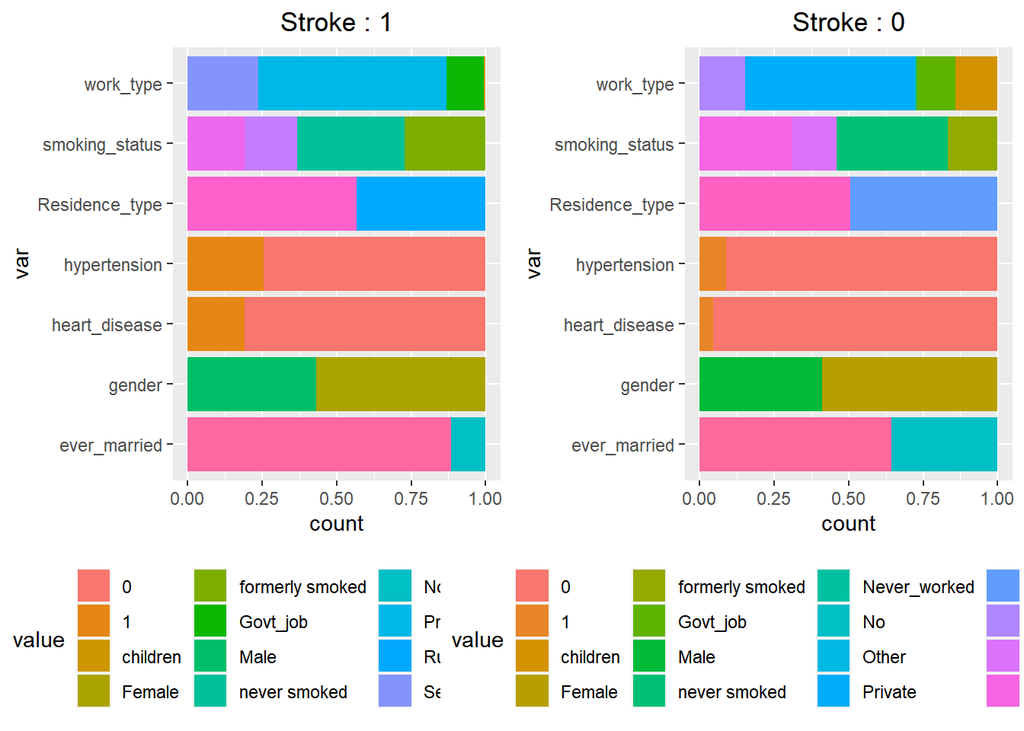

```r
mydata$hypertension <- as.factor(mydata$hypertension)
mydata$heart_disease <- as.factor(mydata$heart_disease)
visual_data <- mydata[,sapply(mydata, is.factor) | colnames(mydata) %in% c("stroke")]

visual_data_0 <- visual_data %>%
  filter(stroke == 0)
visual_data_1 <- visual_data %>%
  filter(stroke == 1)
gplot1 <- gather(visual_data_0, key = "var", value = "value", -stroke) %>%
  ggplot(aes(x = var, fill = value)) +
  geom_bar(position = "fill") +
  coord_flip() +
  theme(legend.position= "bottom") +
  ggtitle("Stroke : 0") +
  theme(plot.title = element_text(hjust = 0.5))
gplot2 <- gather(visual_data_1, key = "var", value = "value", -stroke) %>%
  ggplot(aes(x = var, fill = value)) +
  geom_bar(position = "fill") +
  coord_flip() +
  theme(legend.position= "bottom") +
  ggtitle("Stroke : 1") +
  theme(plot.title = element_text(hjust = 0.5))
grid.arrange(gplot2, gplot1, nrow = 1)
```

### 문제 5. 타겟(stoke)값 별로 수치형 변수의 분포를 다음과 같이 시각화 하고, 간단히 해석해보세요.(gather, gridExtra 패키지 내 함수 이용).

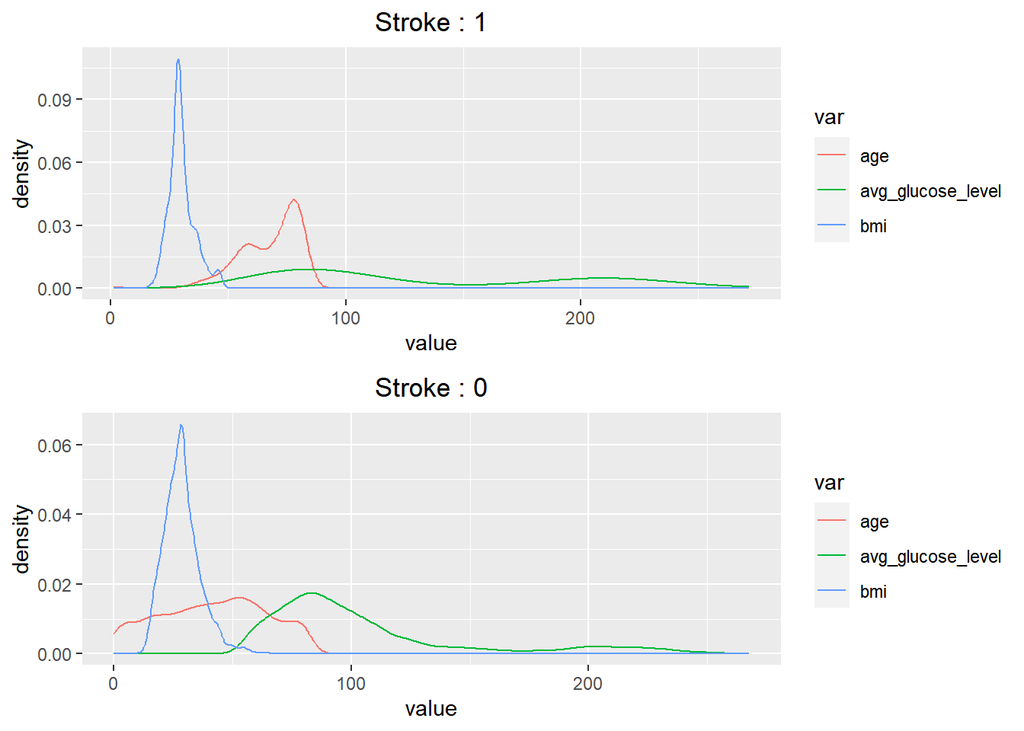

```r
visual_data_num <- mydata[,sapply(mydata, is.numeric) | colnames(mydata) %in% c("stroke")]

visual_data_num_0 <- visual_data_num %>%
  filter(stroke == 0)
visual_data_num_1 <- visual_data_num %>%
  filter(stroke == 1)

num_gplot1 <- gather(visual_data_num_0, key = "var", value = "value", -stroke) %>%
  ggplot(aes(x = value, color = var)) +
  geom_line(stat = "density") +
  ggtitle("Stroke : 0") +
  theme(plot.title = element_text(hjust = 0.5))

num_gplot2 <- gather(visual_data_num_1, key = "var", value = "value", -stroke) %>%
  ggplot(aes(x = value, color = var)) +
  geom_line(stat = "density") +
  ggtitle("Stroke : 1") +
  theme(plot.title = element_text(hjust = 0.5))

grid.arrange(num_gplot2, num_gplot1, nrow = 2)
```

bmi 값의 분포는 비슷하다 글루코젠 지수(?)는 stroke가 0인 쪽이 평균값에 좀 더 몰려있는 분포를 나타낸다 나이의 경우 stroke가 0인쪽에서 젊은 사람의 비율이 높음을 알 수 있다.

### 문제 6. 타겟 변수와 범주형 변수에 대한 카이스퀘어 독립성 검정을 진행하고 다음과 같이 출력하세요. (데이터프레임을 만든 후, for 문으로 독립성 검정을 진행하여 chi 변수에 검정 결과를 넣으세요.)

```r
chi_base_data <- mydata[,sapply(mydata, is.factor) | colnames(mydata) %in% c("stroke")]

chi_data <- data.frame(cate_var = colnames(chi_base_data)[1:7], chi = c(NA,NA,NA,NA,NA,NA,NA))


for(i in 1:7){
  chi_result <- chisq.test(table(chi_base_data[,i], chi_base_data$stroke), correct = F)
  chi_data[i,2] <- ifelse(chi_result$p.value < 0.05,"denied","accpet")
}
```

[output not shown]

### 문제 7. 카이스퀘어 독립성 검정에서 가설을 기각하지 못한 범주형 변수를 제거하세요.

```r
mydata <- mydata[, !colnames(mydata) %in% c('gender','Residence_type')]
```

### 문제 8. train data에서 했던 전처리 방법들을 사용하여 전처리 하세요

```r
mytest$bmi <- as.numeric(mytest$bmi)
mytest$bmi <- ifelse(is.na(mytest$bmi), mean(mytest$bmi,na.rm= T),mytest$bmi)
mytest$hypertension <- as.factor(mytest$hypertension)
mytest$heart_disease <- as.factor(mytest$heart_disease)

mytest <- data.frame(lapply(mytest, function(x) {
  if(is.character(x)) as.factor(x) else x}))

mytest <- mytest[, !colnames(mytest) %in% c('id','gender','Residence_type')]
```

# Chapter 2. Catboost

### 문제 0. Catboost 모델의 특성 및 대표적인 파라미터에 대해 간단히 설명하세요.

Catboost 모델의 가장 큰 틍직은 범주형 변수를 처리하는데 유용하다는 것이다. Catboost는 일부 데이터만을 가지고 잔차계산을 하고 모델을 만든 후, 데이터의 잔차는 이 모델로 예측한 값을 사용한다. (Ordered Boosting)

대표 파라미터 : one_hot_max_size => Cardinality가 설정한 값 이하인 범주형 변수들은 Target Encoding이 아니라 One-hot으로 인코딩

### 문제 1. expand.grid를 사용하여 다음과 같은 데이터 프레임을 만드세요. (데이터 프레임명: logloss_cb)

```r
library(catboost)
library(caret)
library(MLmetrics)
logloss_cb <- expand.grid(depth  = c(4,6,8), iterations = c(100,200), logloss = NA)

logloss_cb
```

```
##   depth iterations logloss
## 1     4        100      NA
## 2     6        100      NA
## 3     8        100      NA
## 4     4        200      NA
## 5     6        200      NA
## 6     8        200      NA
```

### 문제 2. Catboost에 대해 depth와 iteration 파라미터 튜닝을 위한 grid search 5-fold CV를 진행하세요.

```r
set.seed(1234)

train_folds <- createFolds(mydata$stroke, k=5)

start <- Sys.time()
for(i in 1:nrow(logloss_cb)){
  cvacc <- NULL
  for(k in 1:5){
    cv_train = mydata[-train_folds[[k]], ]
    cv_test = mydata[train_folds[[k]], ]

    train_pool <- catboost.load_pool(data = cv_train[,1:6],
                   label = cv_train[,"stroke"],
                   cat_features = which(sapply(cv_train[,x], is.factor)))
    test_pool <- catboost.load_pool(data = cv_test[,1:6],
                   label = cv_test[,"stroke"],
                   cat_features = which(sapply(cv_test[,x], is.factor)))

    params <- list(iterations=logloss_cb[i,2],
               depth = logloss_cb[i,1],
               loss_function = 'Logloss',
               random_seed = 1234,
               train_dir = "CatBoost_output")

    CatBoost <- catboost.train(learn_pool = train_pool,
                               test_pool = test_pool,
                               params = params)
    test_error <- read.table("CatBoost_output/test_error.tsv",
                             sep = '\t',
                             header = TRUE)
    cvacc[k]<- test_error$Logloss
  }
  logloss_cb[i,3] <- mean(cvacc)
}

CatBoost_Runtime <- Sys.time() - start
```

```r
CatBoost_Runtime
```

```
## Time difference of 44.50237 secs
```

```r
logloss_cb
```

```
##   depth iterations   logloss
## 1     4        100 0.6049639
## 2     6        100 0.6052324
## 3     8        100 0.6052324
## 4     4        200 0.5625863
## 5     6        200 0.5614417
## 6     8        200 0.5614417
```

### 문제 3. logloss_cb에서 가장 낮은 logloss 값의 행을 출력하세요

```r
logloss_cb %>%
  filter(logloss == min(logloss))
```

```
##   depth iterations   logloss
## 1     6        200 0.5614417
## 2     8        200 0.5614417
```

### 문제 4. 가장 낮은 logloss 값의 파라미터로 전체 데이터를 학습시켜 test set에 대한 logloss값을 구하세요.

```r
train_pool <- catboost.load_pool(data = mydata[,1:6],
                   label = mydata[,"stroke"],
                   cat_features = which(sapply(mydata[,x], is.factor)))
test_pool <- catboost.load_pool(data = mytest[,1:6],
                   label = mytest[,"stroke"],
                   cat_features = which(sapply(mytest[,x], is.factor)))

params <- list(iterations= 200,
               depth = 6,
               loss_function = 'Logloss',
               random_seed = 1234,
               train_dir = "CatBoost_output")

CatBoost <- catboost.train(learn_pool = train_pool,
                               test_pool = test_pool,
                               params = params)
test_error <- read.table("CatBoost_output/test_error.tsv",
                             sep = '\t',
                             header = TRUE)
```

```r
mean(test_error$Logloss)
```

```
## [1] 0.1743838
```

# Chapter 3. K-means Clustering

### 문제 1. 수치형 변수(age, avg_glucose_level, bmi)에 대해 scale 함수로 정규화 스케일링을 하세요.

```r
library(cluster)
library(factoextra)
scale_data <- mydata %>%
  select(age, avg_glucose_level, bmi)


scale_model <- scale_data

for(i in 1:3){
  min_value = min(scale_data[,i])
  max_value = max(scale_data[,i])
  scale_model[,i] = scale(scale_data[,i], center = min_value, scale = max_value - min_value)
}

summary(scale_model)
```

```
##        age.V1        avg_glucose_level.V1       bmi.V1
##  Min.   :0.0000000   Min.   :0.0000000    Min.   :0.0000000
##  1st Qu.:0.3041992   1st Qu.:0.1013301    1st Qu.:0.1534937
##  Median :0.5483398   Median :0.1689913    Median :0.2061856
##  Mean   :0.5262758   Mean   :0.2355905    Mean   :0.2122316
##  3rd Qu.:0.7436523   3rd Qu.:0.2729540    3rd Qu.:0.2565865
##  Max.   :1.0000000   Max.   :1.0000000    Max.   :1.0000000
```

### 문제 2. fviz_nbclust 함수로 다음과 같이 시각화 한 뒤, 적절한 K값이 무엇인지 설명하세요.

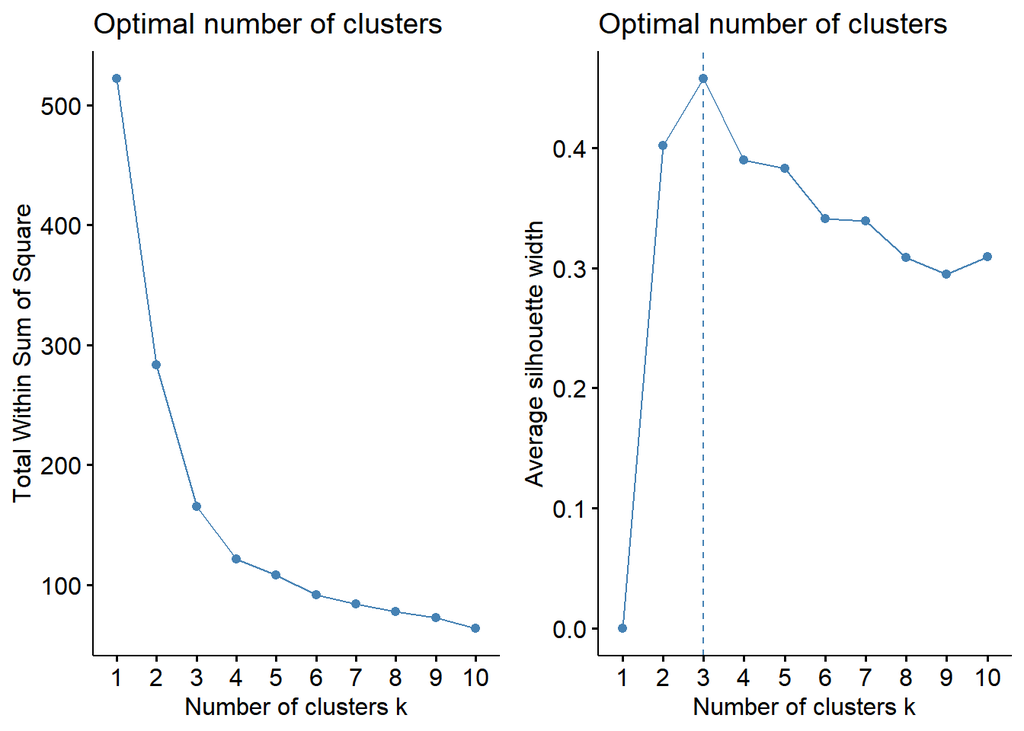

```r
cplot1 <- fviz_nbclust(scale_model, kmeans, method = "wss")
cplot2 <- fviz_nbclust(scale_model, kmeans, method = "silhouette")

grid.arrange(cplot1, cplot2, nrow = 1)
```

왼쪽 그래프에서 k가 4부터 점점 기울기가 완만해지고, 오른쪽에서도 마찬가지이므로 k=3 또는 4가 적절할 것으로 보인다.

### 문제 3. K-means 클러스터링을 한 후, 다음과 같이 시각화하세요. (nstart = 1, iter.max =30, seed: 1234)

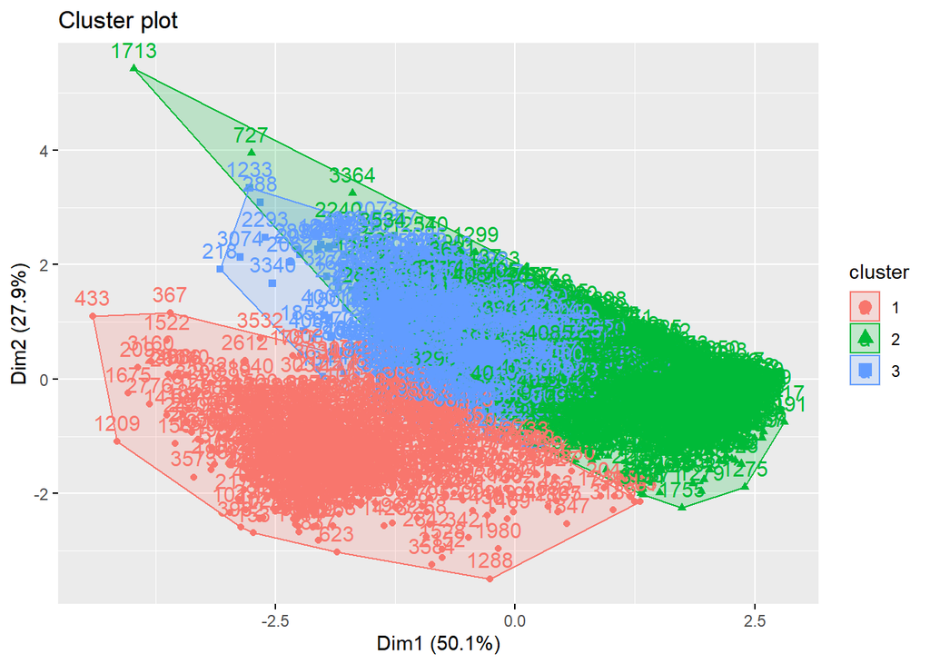

```r
set.seed(1234)

kmeans_data <- kmeans(scale_data, 3, nstart = 1, iter.max = 30)

fviz_cluster(kmeans_data, data = scale_data,
             ellipse.type = "convex"
             )
```

### 문제 4. 사용한 변수인 age, avg_glucose_level(평균 혈당), bmi(bmi 수치)에 대해 다음과 같이 box_plot 시각화를 하고, 클러스터 별로 해석해보세요. (사용 색 : #845ec2, #ffc75f, #ff5e78)

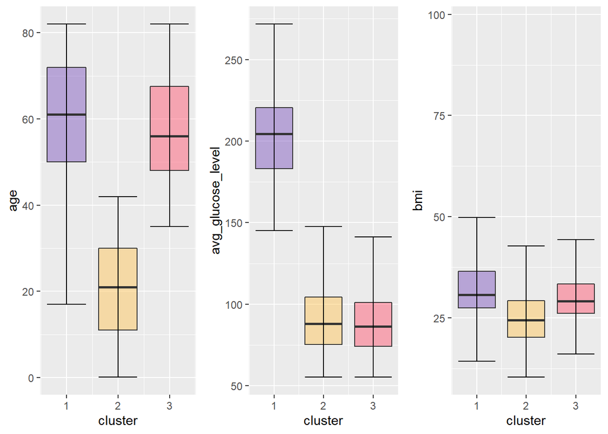

```r
scale_data$cluster <- kmeans_data$cluster




scale_box_bmi <- scale_data %>%
  ggplot(aes(x = cluster, y = bmi, fill = factor(cluster))) +
  geom_boxplot(outlier.shape = NA, alpha = 0.5) +
  stat_boxplot(geom = "errorbar") +
  scale_fill_manual(values = c("#845ec2", "#ffc75f", "#ff5e78")) +
  theme(legend.position =  "none")

scale_box_glu <- scale_data %>%
  ggplot(aes(x = cluster, y = avg_glucose_level, fill = factor(cluster))) +
  geom_boxplot(outlier.shape = NA, alpha = 0.5) +
  stat_boxplot(geom = "errorbar") +
  scale_fill_manual(values = c("#845ec2", "#ffc75f", "#ff5e78")) +
  theme(legend.position =  "none")

scale_box_age <- scale_data %>%
  ggplot(aes(x = cluster, y = age, fill = factor(cluster))) +
  geom_boxplot(outlier.shape = NA, alpha = 0.5) +
  stat_boxplot(geom = "errorbar") +
  scale_fill_manual(values = c("#845ec2", "#ffc75f", "#ff5e78")) +
  theme(legend.position =  "none")

grid.arrange(scale_box_age,scale_box_glu, scale_box_bmi, nrow = 1)
```